# FAS1003: Visualisation des données

# Cours 6: Aspects visuels

# Plan de match

## Les étages de ggplot()

1. les données (`data = ...`)
2. les éléments visuels (`mapping = aes(...)`)
3. les géométries (`geom_`)
4. l’apparence des éléments visuels (`scale_`)
5. les étiquettes (`labs(...)`)
6. **les facettes (`facet_`)**
7. **la manipulation des axes (`coord_`)**
8. **les thèmes (`theme_` et `theme()`)**

## Renommer automatiquement les valeurs sur nos axes (dollars, entre autres)

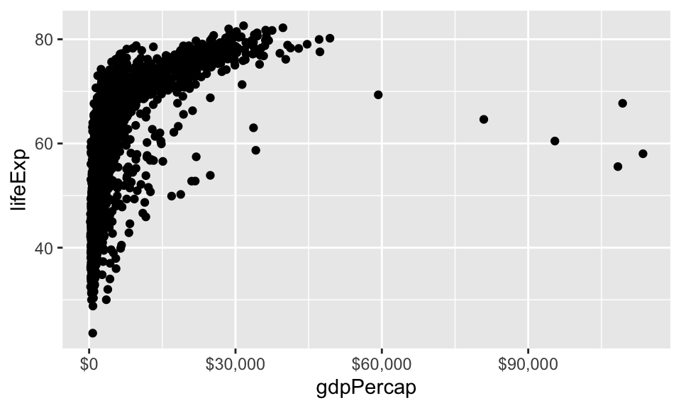

```r
library(gapminder)
dat <- gapminder

ggplot(aes(x = gdpPercap, y = lifeExp), data = dat) +
  geom_point() +
  scale_x_continuous(labels = scales::dollar_format())
```

# Facettes

## Les données du jour

```r
# install.packages("tidytuesdayR")

library(tidytuesdayR)
#data <- tt_load('2021-03-09')
#dat <- data$movies
dat <- readr::read_csv('https://raw.githubusercontent.com/rfordatascience/tidytuesday/master/data/2021/2021-03-09/movies.csv')
```

## Graphique de départ

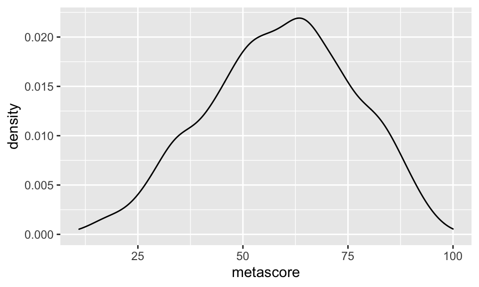

```r
p = ggplot(data = dat, aes(x = metascore)) +
  geom_density()

p
```

## Facettes

Parfois, nous voulons présenter le même graphique, mais pour plusieurs valeurs d’une variable catégorielle.

- Par exemple, avoir 2 nuages de points **dans deux graphiques différents**: un pour le pays X, l’autre pour le pays Y

## Visualiser deux groupes dans un même graphique: jouer avec l’aes()

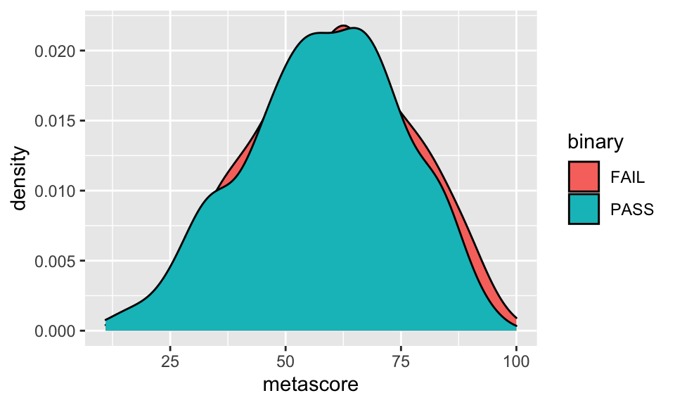

```r
p1 = ggplot(data = dat, aes(x = metascore, fill = binary)) +
  geom_density()

p1
```

## Visualiser deux groupes dans un même graphique: jouer avec l’aes()

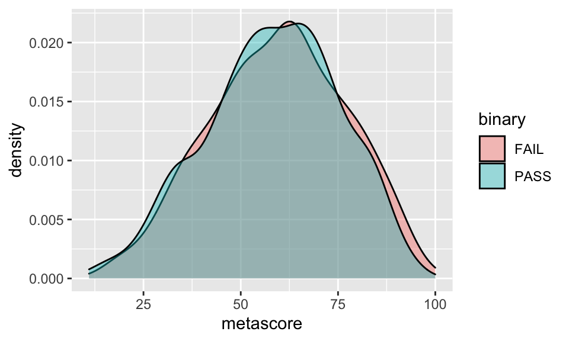

```r
p1 = ggplot(data = dat, aes(x = metascore, fill = binary)) +
  geom_density(alpha = .4)

p1
```

## Visualiser deux groupes dans plusieurs graphiques: facet_wrap()

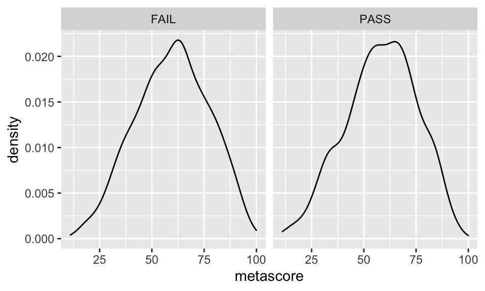

```r
p2 = ggplot(data = dat, aes(x = metascore)) +
  geom_density() +
  facet_wrap(~binary)

p2
```

## Visualiser deux groupes dans plusieurs graphiques: facet_wrap()

Possible de garder les couleurs aussi. (Nous allons voir comment retirer la légende dans un instant.)

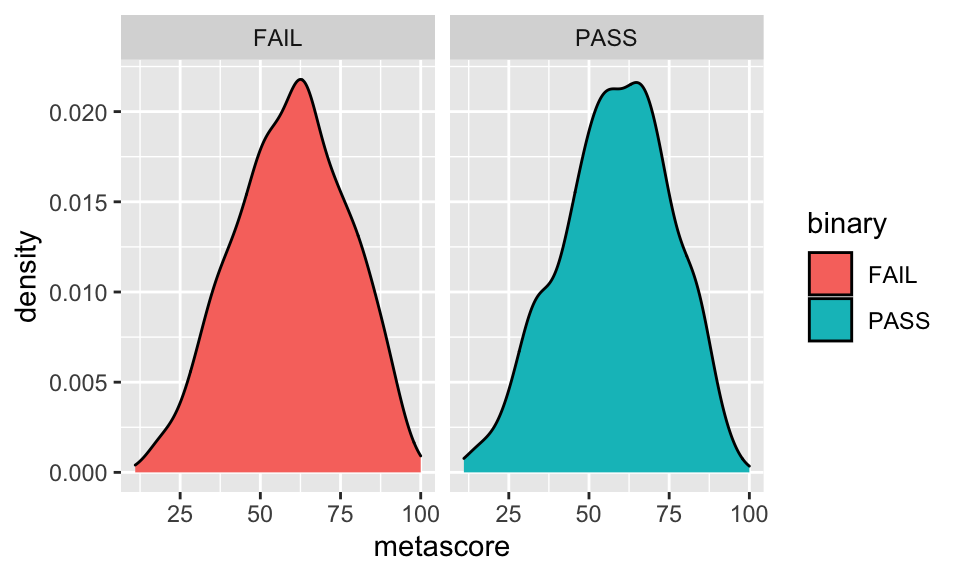

```r
p2 = ggplot(data = dat, aes(x = metascore, fill = binary)) +
  geom_density() +
  facet_wrap(~binary)

p2
```

## facet_wrap(): jouer avec le nombre de colonnes/lignes

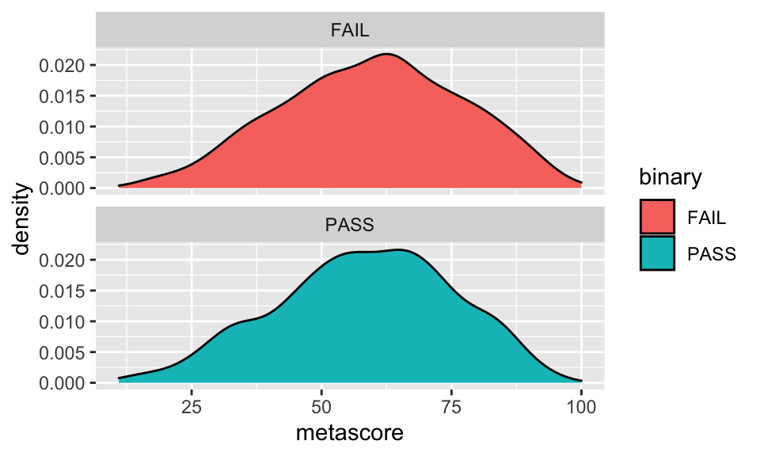

```r
p3 = ggplot(data = dat, aes(x = metascore, fill = binary)) +
  geom_density() +
  facet_wrap(~binary, ncol = 1)

p3
```

## facet_wrap(): jouer avec le nombre de colonnes/lignes

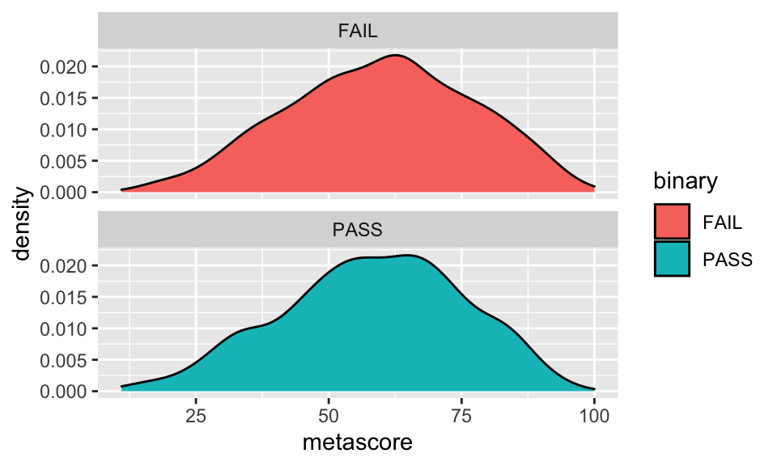

```r
p3 = ggplot(data = dat, aes(x = metascore, fill = binary)) +
  geom_density() +
  facet_wrap(~binary, nrow = 2)

p3
```

## facet_wrap(): ajuster tout le reste

Rappelez-vous: ggplot() fonctionne par étage. Il est donc tout à fait possible d’ajouter les autres étages que nous avons vus précédemment!

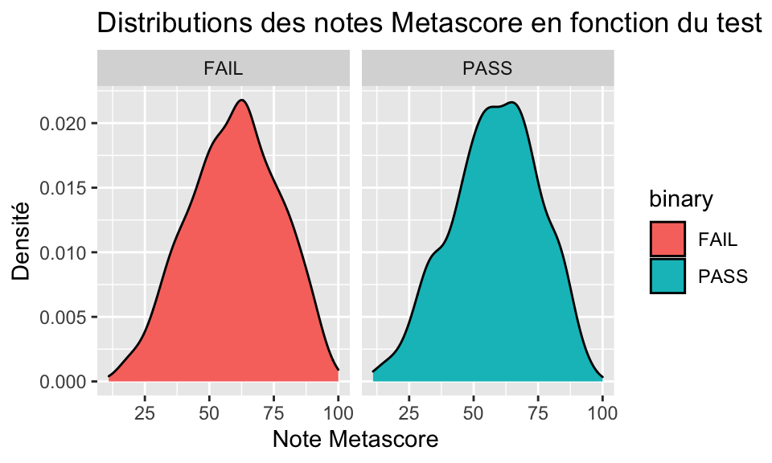

```r
p3 = ggplot(data = dat, aes(x = metascore, fill = binary)) +
  geom_density() +
  labs(title = "Distributions des notes Metascore en fonction du test Bechdel",
       x = "Note Metascore",
       y = "Densité") +
  facet_wrap(~binary)

p3
```

## facet_wrap(): changer les noms des facettes?

- Façon 1: Recoder la variable en question (avec `mutate()` et `recode()`, par exemple)
- Façon 2: Utiliser l’argument `labeller()` à l’intérieur de `facet_wrap()`
- Sûrement d’autres façons ;)

## Utiliser l’argument `labeller()` à l’intérieur de `facet_wrap()`

Utiliser l’argument `labeller()` à l’intérieur de `facet_wrap()`

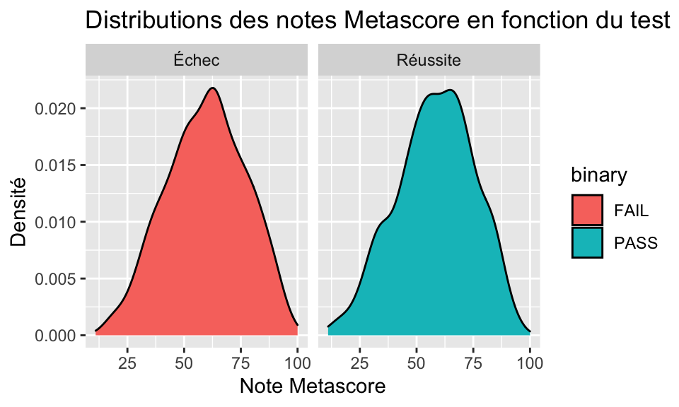

```r
binary_noms <- c("FAIL" = "Échec",
                 "PASS" = "Réussite")

p4 = ggplot(data = dat, aes(x = metascore, fill = binary)) +
  geom_density() +
  labs(title = "Distributions des notes Metascore en fonction du test Bechdel",
       x = "Note Metascore",
       y = "Densité") +
  facet_wrap(~binary, labeller = as_labeller(binary_noms))

p4
```

# Coordonnées cartésiennes

## coord_cartesian()

La fonction `coord_cartesian()` permet de faire un zoom sur le graphique.

```r
class(dat$domgross_2013)
```

```
## [1] "character"
```

```r
dat$domgross_2013 <- as.numeric(dat$domgross_2013)
class(dat$domgross_2013)
```

```
## [1] "numeric"
```

## coord_cartesian()

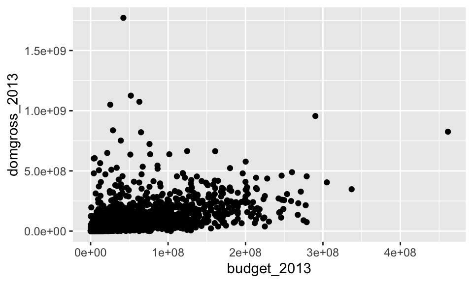

```r
p = ggplot(data = dat, aes(x = budget_2013, y = domgross_2013))+
  geom_point()

p
```

## coord_cartesian()

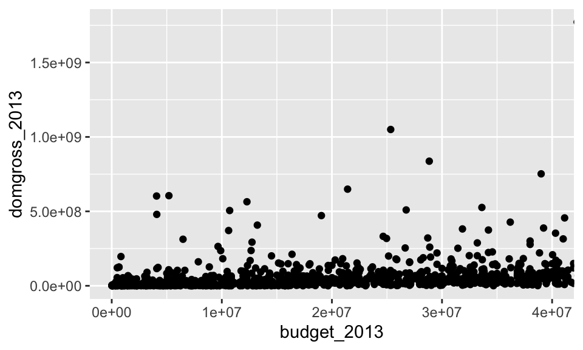

```r
# Entre 0 et 40 000 000$ de budget.
p1 = p +
  coord_cartesian(xlim = c(0,40000000))

p1
```

## Pourquoi pas `limits`?

Quelle est la différence entre `coord_cartesian()` et `limits`?

- `limits` supprime les observations qui se trouvent à l’extérieur de l’étendue choisie.
- `coord_cartesian()` fait un “zoom”. Les observations sont toujours là, mais on ne les voit plus (elles se trouvent à l’extérieur du cadre).

## `coord_cartesian()` vs. `limits`: ce que ça change

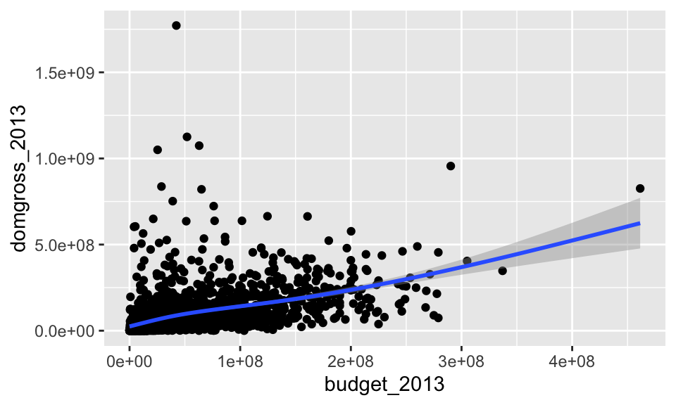

```r
p2 = ggplot(data = dat, aes(x = budget_2013, y = domgross_2013))+
  geom_point() +
  geom_smooth()

p2
```

## `coord_cartesian()` vs. `limits`: ce que ça change

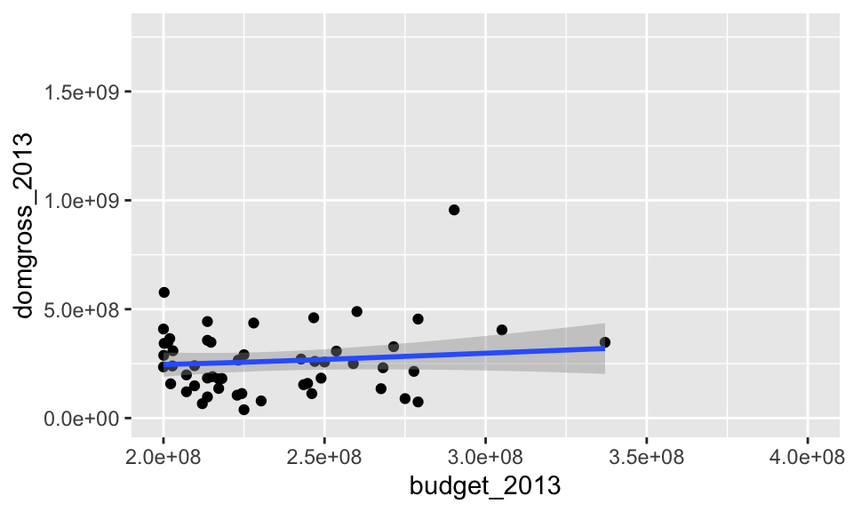

```r
# Entre 200 000 000 et 400 000 000$.
p3 = ggplot(data = dat, aes(x = budget_2013, y = domgross_2013))+
  geom_point() +
  geom_smooth() +
  scale_x_continuous(limits = c(200000000,400000000))

p3
```

## `coord_cartesian()` vs. `limits`: ce que ça change

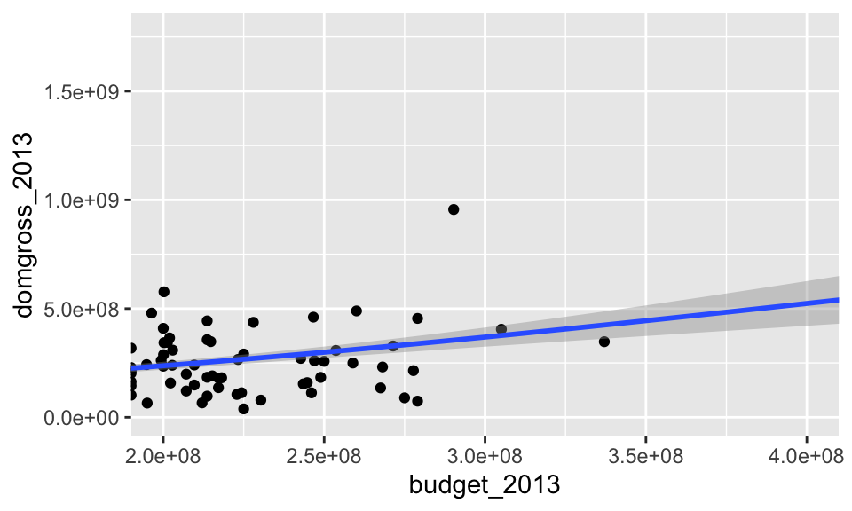

```r
# Entre 200 000 000 et 400 000 000$.
p4 = ggplot(data = dat, aes(x = budget_2013, y = domgross_2013))+
  geom_point() +
  geom_smooth() +
  coord_cartesian(xlim = c(200000000,400000000))

p4
```

## coord_flip()

`coord_flip()` permet d’inverser l’axe des x et l’axe des y.

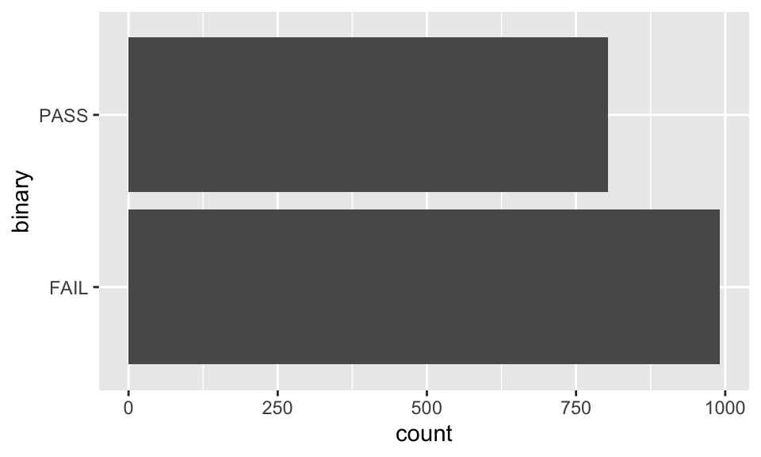

```r
p = ggplot(data = dat, aes(x = binary))  +
  geom_bar() +
  coord_flip()

p
```

# Exercice 1

## Exercice 1

1. Créez un nuage de points avec la variable `budget` sur l’axe des x et `intgross` sur l’axe des y. Créez une facette pour chaque catégorie de la variable `clean_test`.
2. Spécifiez l’opacité des points à 0.4. Ajoutez une ligne de régression pour chauque facette. Limitez les coordonnées cartésiennes à un maximum de 200 000 000$ de budget.

## Exercice 1 (corrigé)

1. Créez un nuage de points avec la variable `budget` sur l’axe des x et `intgross` sur l’axe des y. Créez une facette pour chaque catégorie de la variable `clean_test`.

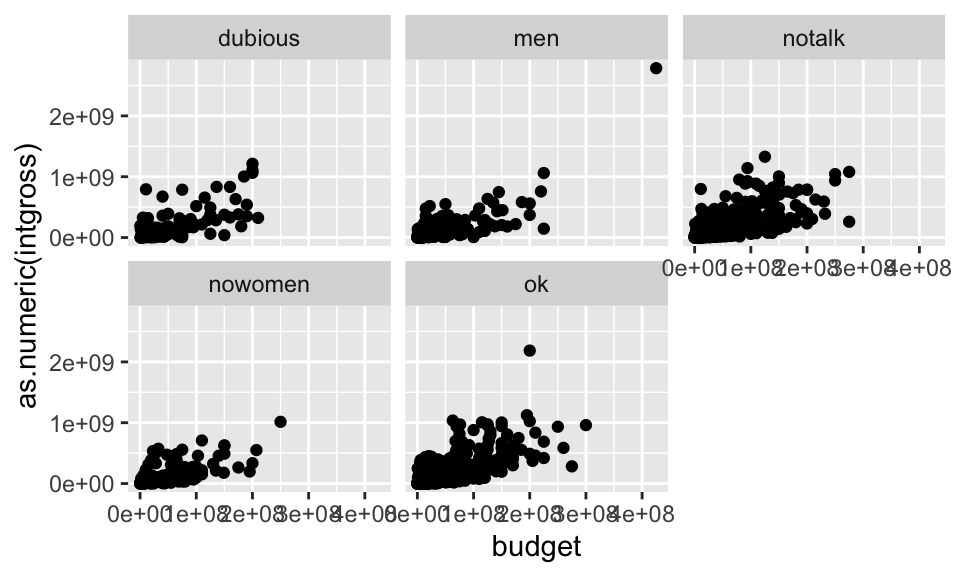

```r
ggplot(data = dat, aes(x = budget, y = as.numeric(intgross))) +
  geom_point() +
  facet_wrap(~clean_test)
```

## Exercice 1 (corrigé)

2. Spécifiez l’opacité des points à 0.4. Ajoutez une ligne de régression pour chauque facette. Limitez les coordonnées cartésiennes à un maximum de 200 000 000$ de budget.

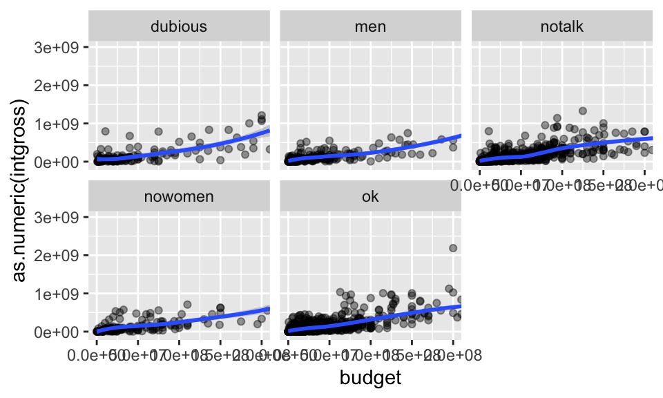

```r
ggplot(data = dat, aes(x = budget, y = as.numeric(intgross))) +
  geom_point(alpha = .4) +
  geom_smooth() +
  facet_wrap(~clean_test) +
  coord_cartesian(xlim = c(0,200000000))
```

# Les thèmes

## Les thèmes pré-existants

- Les thèmes permettent de modifier presque tous les aspects visuels restants (couleur de l’arrière-plan, du quadrillage, emplacement des mots, etc.)
- Comme pour les palettes de couleurs, des thèmes pré-existants existent déjà.
- Quelques exemples…

## Les thèmes pré-existants

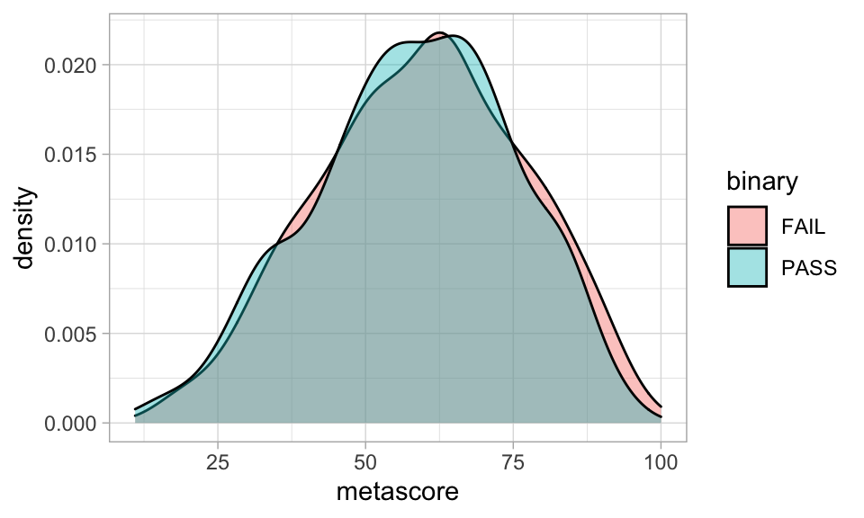

```r
ggplot(data = dat, aes(x = metascore, fill = binary)) +
  geom_density(alpha = .4) +
  theme_light()
```

## Les thèmes pré-existants

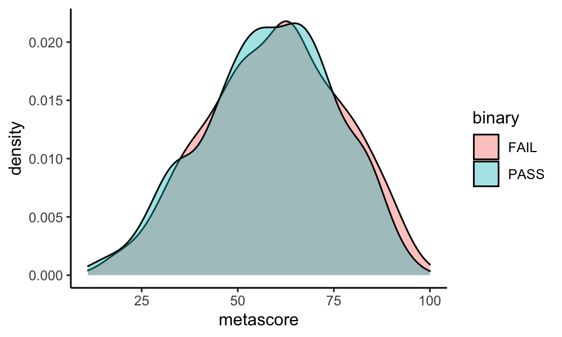

```r
ggplot(data = dat, aes(x = metascore, fill = binary)) +
  geom_density(alpha = .4) +
  theme_classic()
```

## Les thèmes pré-existants

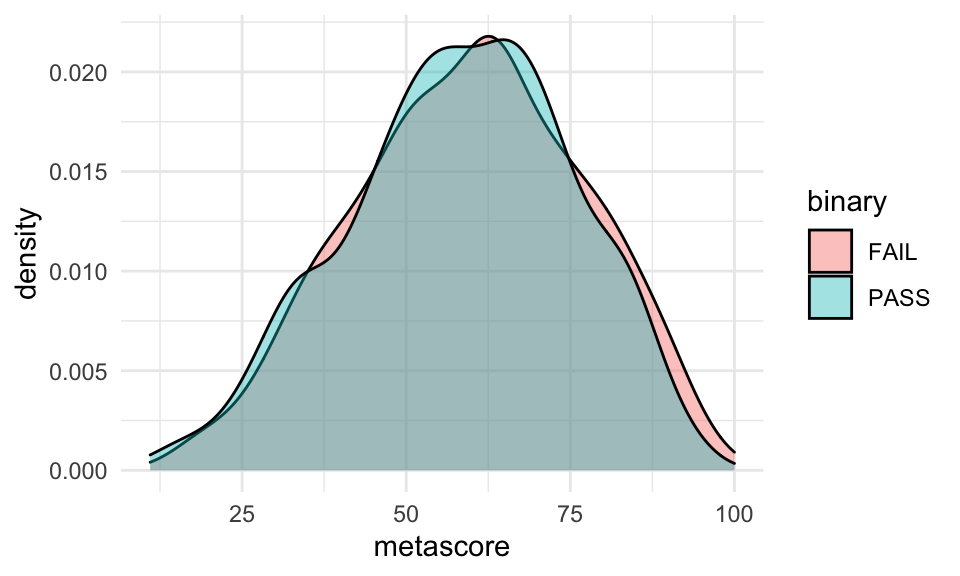

```r
ggplot(data = dat, aes(x = metascore, fill = binary)) +
  geom_density(alpha = .4) +
  theme_minimal()
```

## Les thèmes pré-existants

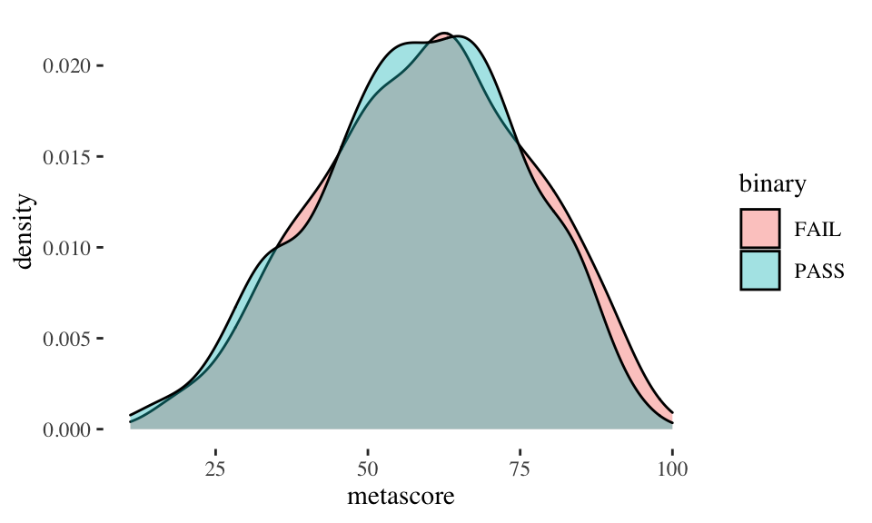

```r
#install.packages("ggthemes")
library(ggthemes)

ggplot(data = dat, aes(x = metascore, fill = binary)) +
  geom_density(alpha = .4) +
  theme_tufte() # Edward Tufte
```

## Les thèmes pré-existants

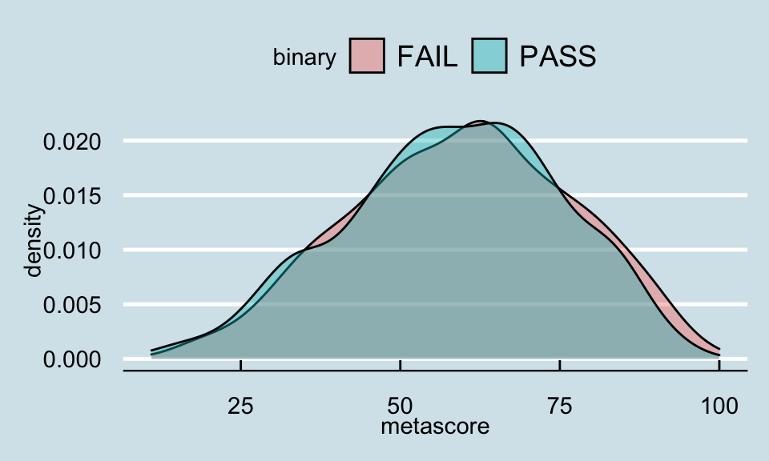

```r
ggplot(data = dat, aes(x = metascore, fill = binary)) +
  geom_density(alpha = .4) +
  theme_economist() # The Economist
```

## Les thèmes pré-existants

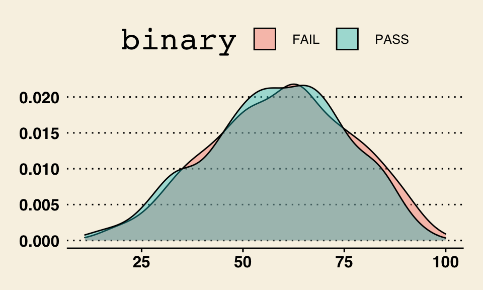

```r
ggplot(data = dat, aes(x = metascore, fill = binary)) +
  geom_density(alpha = .4) +
  theme_wsj() # Wall Street Journal
```

## Modifier le thème manuellement

```r
?theme
```

Références pour les éléments qui se retrouvent dans `theme()`:

- https://isabella-b.com/blog/ggplot2-theme-elements-reference/
- https://ggplot2.tidyverse.org/reference/theme.html

## Position de la légende

- Cibler un élément: `axis.title.x()`, `legend.position()`, `plot.subtitle()`, etc.
- Puis, modifier un aspect spécifique de cet élément: `element_text()`, `element_rect()`, `element_line()`, `element_blank()`

## Exemple: Position des titres d’axes

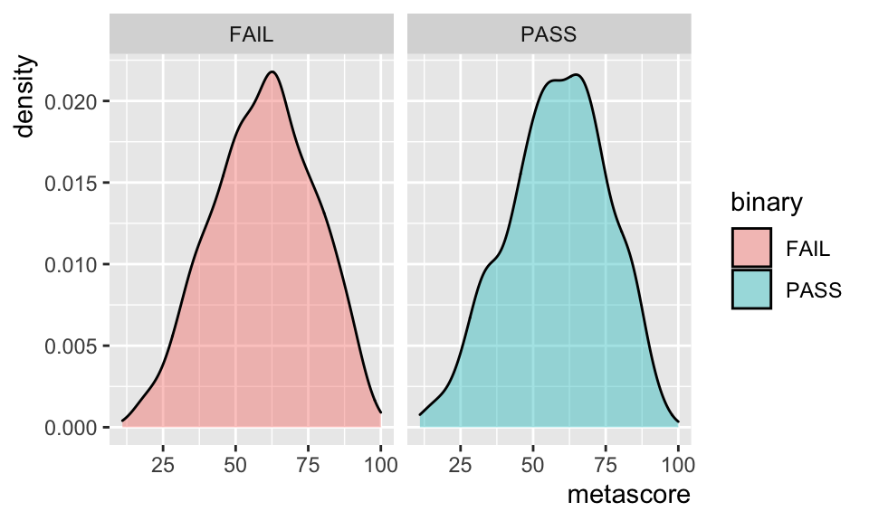

```r
ggplot(data = dat, aes(x = metascore, fill = binary)) +
  geom_density(alpha = .4) +
    facet_wrap(~binary) +
  theme(axis.title = element_text(hjust = 1))
```

## Exemple: Enlever la légende

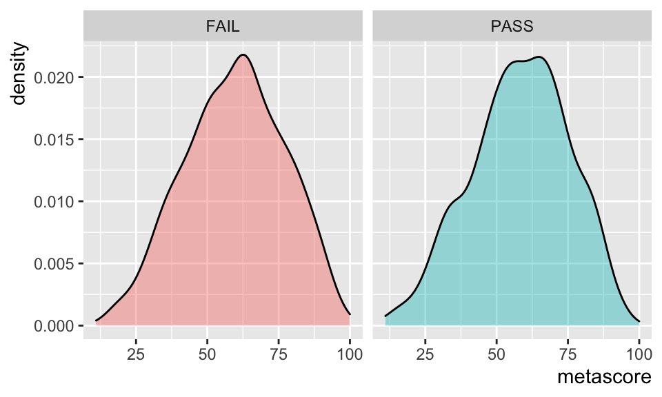

```r
ggplot(data = dat, aes(x = metascore, fill = binary)) +
  geom_density(alpha = .4) +
  facet_wrap(~binary) +
  theme(axis.title = element_text(hjust = 1),
        legend.position = "")
```

## Exemple: Agrandir la taille du titre

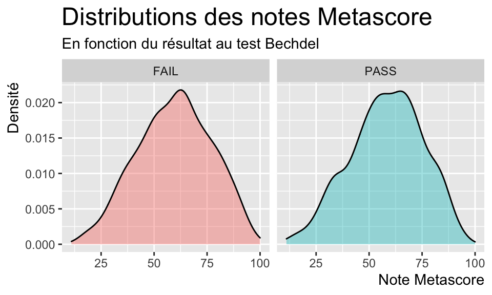

```r
ggplot(data = dat, aes(x = metascore, fill = binary)) +
  geom_density(alpha = .4) +
  facet_wrap(~binary)+
  labs(title = "Distributions des notes Metascore",
       subtitle = "En fonction du résultat au test Bechdel",
       x = "Note Metascore",
       y = "Densité") +
  theme(axis.title = element_text(hjust = 1),
        legend.position = "",
        plot.title = element_text(size = 18))
```

## Exemple: Changer la couleur du fond

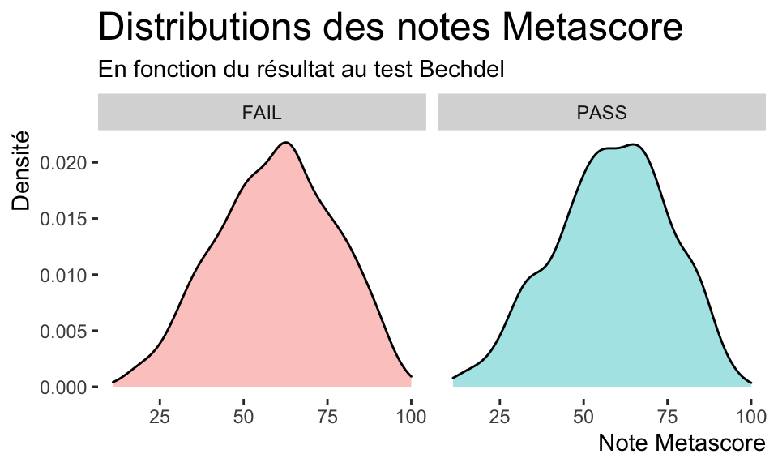

```r
ggplot(data = dat, aes(x = metascore, fill = binary)) +
  geom_density(alpha = .4) +
  facet_wrap(~binary)+
  labs(title = "Distributions des notes Metascore",
       subtitle = "En fonction du résultat au test Bechdel",
       x = "Note Metascore",
       y = "Densité") +
  theme(axis.title = element_text(hjust = 1),
        legend.position = "",
        plot.title = element_text(size = 18),
        panel.background = element_rect(fill = "white"))
```

## Modifier le thème manuellement

Et des centaines d’autres combinaisons !

# Exercice 2

## Exercice 2

1. Sélectionnez seulement les films produits par Steven Spielberg (`director`).
2. Créez un nuage de points avec la variable `year` sur l’axe des x et `budget_2013` sur l’axe des y. Ajoutez aussi une ligne qui traverse tous les points.
3. Spécifiez la taille des points à 2. Faites varier la couleur des points en fonction de la variable `clean_test`.
4. Ajoutez un titre, modifiez le nom des axes et traduisez la légende en français. Faites en sorte que les étiquettes de l’axe des y soient en dollars. Changez le thème pour un thème pré-existant de votre choix.

## Exercice 2 (corrigé)

1. Sélectionnez seulement les films produits par Steven Spielberg (`director`).

```r
dat_court = dat %>% filter(director == "Steven Spielberg")
```

## Exercice 2 (corrigé)

2. Créez un nuage de points avec la variable `year` sur l’axe des x et `budget_2013` sur l’axe des y. Ajoutez aussi une ligne qui traverse tous les points.

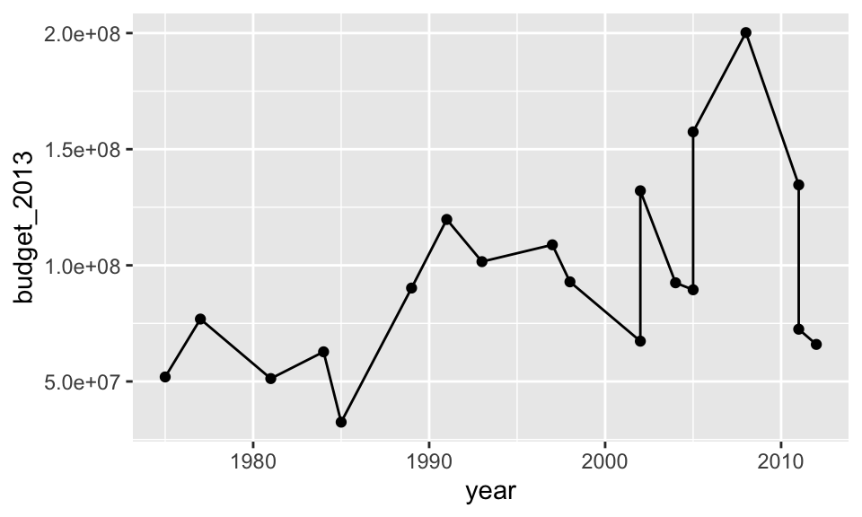

```r
ggplot(data = dat_court, aes(x =  year, y = budget_2013)) +
  geom_point() +
  geom_line()
```

## Exercice 2 (corrigé)

3. Spécifiez la taille des points à 2. Faites varier la couleur des points en fonction de la variable `clean_test`.

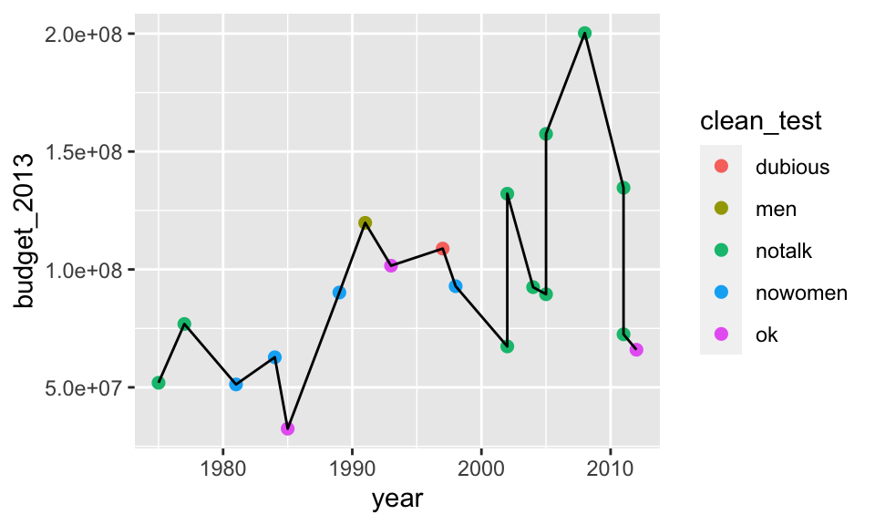

```r
ggplot(data = dat_court, aes(x =  year, y = budget_2013)) +
  geom_point(size = 2, aes(color = clean_test)) +
  geom_line()
```

## Exercice 2 (corrigé)

4. Ajoutez un titre, modifiez le nom des axes et traduisez la légende en français. Faites en sorte que les étiquettes de l’axe des y soient en dollars. Changez le thème pour un thème pré-existant de votre choix.

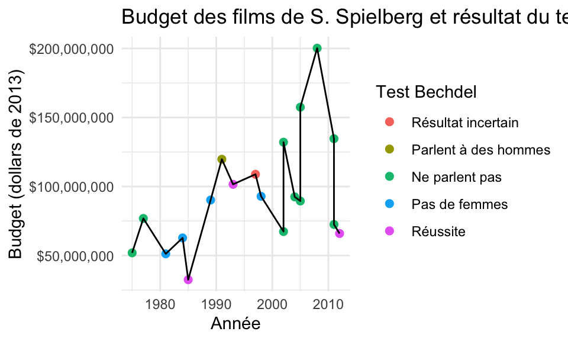

```r
ggplot(data = dat_court, aes(x =  year, y = budget_2013)) +
  geom_point(size = 2, aes(color = clean_test)) +
  geom_line() +
  scale_y_continuous(labels = scales::dollar_format()) +
  scale_color_discrete(name = "Test Bechdel",
                       labels = c("Résultat incertain", "Parlent à des hommes",
                                  "Ne parlent pas", "Pas de femmes",
                                  "Réussite")) +
  labs(title = "Budget des films de S. Spielberg et résultat du test Bechdel",
       x = "Année",
       y = "Budget (dollars de 2013)") +
  theme_minimal()
```